# GU5243 Project1 Data Story

# Sentiment Analysis

Beside analyzing the similarity of the use of words, I am also interested in exploring whether there are some similarity of sentiment coveyed through the text of different schools. In the following section, I use the nrc lexicon to get the sentiment of the words in the philosophy text. I will analyze the distribution of different type of emotions, and use K-Means clustering to see the relationship between schools according to their sentiment score.

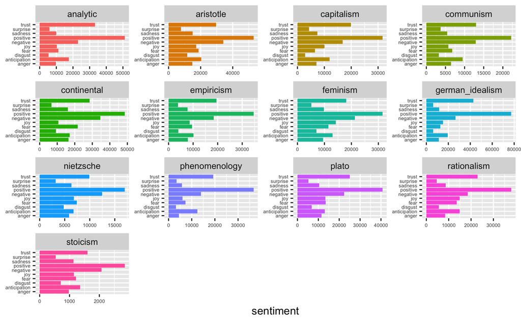

The above plot displays the distribution of sentiment in the text of each school. It is surprising that all classes show a similar distribution. The words with positive sentiment appear always the most frequent in all classes and words with either trust or negative sentiment is the second most common in the text.

Since the above plot shows only a very general distribution of sentiment in text, to see the connection and the similarity of sentiment conveyed through the text of schools, we conduct the K-Means Clustering again to group schools into 3 groups according to their sentiment distribution. Here, I use the counts of each type of sentiment in the text from each schools as features.

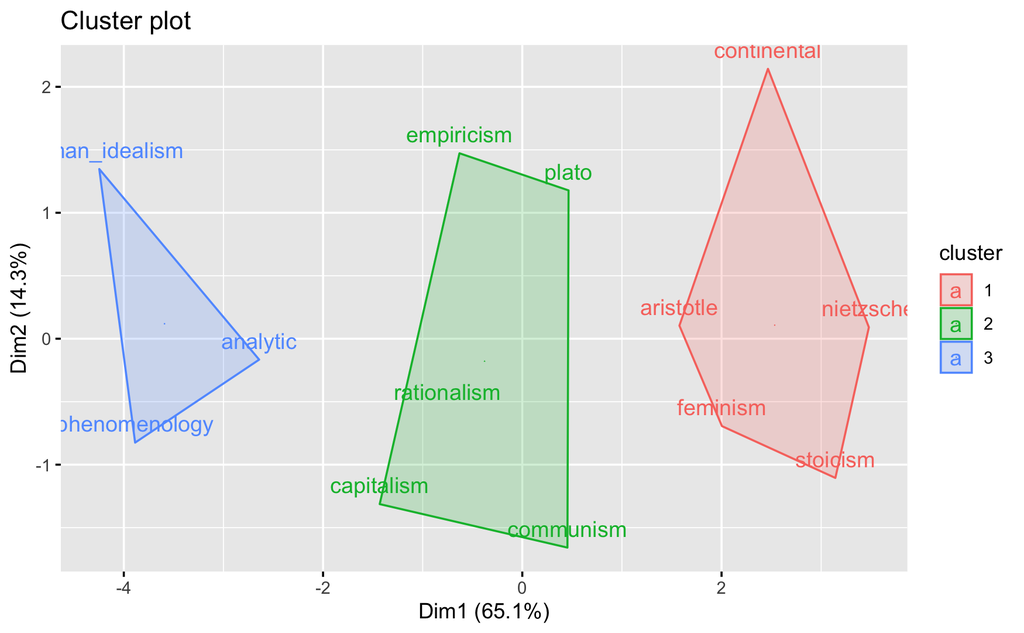

The clustering result shows that the Phenomenology, Analytic and German Idealism are grouped together. The Capitalism, Rationalism, Communism, Plato and Empiricism are in the same group and Continental, Aristotle, Feminism, Nietzsche and Stoicism are in the same group according to their distribution of sentiment.

Also, we can find that the clustering result according to the sentiment distribution is somehow similar to the clustering result according to the word frequency. We see that Phenomenology, Analytic and German Idealism are in the same group in both cases. Communism, Capitalism and Plato are also in the same group in both cases. Moreover, Empiricism and Rationalism are grouped together in both clustering. This means that these schools are related to each other in their use of words, as well as the sentiment they try to convey.

# Conclusion